# Day 3 - Bayesian

```r
setwd("~/Documents/Monash/PhD/R/MurrayLoganStatCourse14")
```

With frequentist it is almost impossible *not* to disprove the null-hypothesis, as the probability of the data is calculated from the data. We are not interested in the sample, we are interested in the population.

```
                   *Frequentist*       *Bayesian*
Observed data     One possible          Fixed, true
Parameters        Fixed, true           Random, distribution
Inferences        Data                  Parameters
Probability       Long-run frequence    Degree of belief
                    $(P|H)$               $P(H|D)$
```

With the Frequentist approach you get one point value for the slope, with the Bayesian you get a distribution. When 90% of this distribution lies above or below zero, you can consider that there is an effect in the data.

*Bayes rule*

*P*(*H*|*D*) = (*P*(*D*|*H*) * P(*H*)) / *P*(*D*)

posterior probability = ( likelyhood x prior probability) / normalizing constant

Propability distribution: area under curve must be 1 Likelihood distribution: are under curve is unknown

Above formula normalizes the area under the curve and makes it equal to 1

**Bayesian is robust to:**

> unequal sample sizes

> balance

> collinearity

> pair-wise comparisons (no need for *post-hoc* tests)

**MCMC-Sampling**

Random walks on distribution. Will always accept a position with a higher probability and whether or not a lower probability point is accepted depends on the actual likelihood of that point. For this reason, we will get a better overview of more probable parts of the distribution. This chain of walks is called a chain!

- Run 3 chains to make sure this is the distribution
- Burning: run for example for a 1000 steps (50% of the actual iterations you want to run) and see what an appropriate distance per step is. After this burning, chuck this burning run out.
- Number of iterations: determined by diagnostics that are run

Start with 10000 iterations and make trace plots:

- needs to be total chaos, when not, include more iterations
- needs to be repeatable

Autocorrelation

- ACF plot
- thinning, thinning factor 10 means only sample every 10th point. When thinning, make sure to increase the number of iterations.

Distribution plots

- multiple modes –> not one single population sampled
- highly skewed –> take median or mode
- area under curve is 1
- credibility intervals (same as confidence interval)

MCMCglmm is not too highly developed in R… Alternative is WinBUGS or JAGS (C++). These programs use a Gibbs sampler. This changes one parameter at a time (for example first intercept, then slope). Better samplers exist, one of which is implemented in STAND.

In C++ not everything has to be scripted in the same order, but everything **will be run simultaneously**

JAGS can be run through other platforms requires and 3 inputs:

- file with model statement
- data in the form of a list
- parameters that define the run (number of iterations, burning etc)

From R: R2Jags

Start as simple as possible, get something to compare to

```r
fert <- read.csv('fertilizer.csv',strip.white=T)
summary(lm(YIELD~FERTILIZER,data=fert))
```

```
##
## Call:
## lm(formula = YIELD ~ FERTILIZER, data = fert)
##
## Residuals:
##    Min     1Q Median     3Q    Max
## -22.79 -11.07  -5.00  12.00  29.79
##
## Coefficients:
##             Estimate Std. Error t value Pr(>|t|)
## (Intercept) 51.93333   12.97904   4.001  0.00394 **
## FERTILIZER   0.81139    0.08367   9.697 1.07e-05 ***
## ---
## Signif. codes:  0 '***' 0.001 '**' 0.01 '*' 0.05 '.' 0.1 ' ' 1
##
## Residual standard error: 19 on 8 degrees of freedom
## Multiple R-squared:  0.9216, Adjusted R-squared:  0.9118
## F-statistic: 94.04 on 1 and 8 DF,  p-value: 1.067e-05
```

To get the contents of the package, type `MCMCpack:::`

This package only runs one chain at the time, so it should be run 3 times

```r
fert.mcmc1 <- MCMCregress(YIELD~FERTILIZER, data=fert,
                          burnin = 100, mcmc =1000, thin=1,seed=1)
```

Seed: the random seed, which dictates how the randomization works. So if you want to run another random run, select another seed:

```r
fert.mcmc2 <- MCMCregress(YIELD~FERTILIZER, data=fert,
                          burnin = 100, mcmc =1000, thin=1,seed=2)
fert.mcmc3 <- MCMCregress(YIELD~FERTILIZER, data=fert,
                          burnin = 100, mcmc =1000, thin=1,seed=3)
```

Now merge them together so you have one object which you can process together.

```r
fert.mcmc <-as.mcmc.list(list(fert.mcmc1,fert.mcmc2,fert.mcmc3))
```

Now take advantage of things that are within coda, like the plotting function

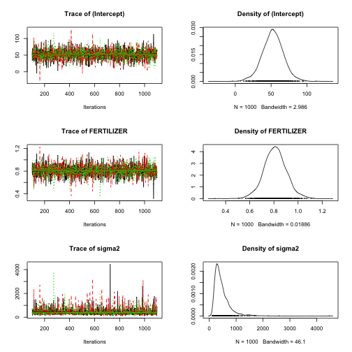

```r
plot(fert.mcmc)
```

> Top row: intercept Middle row: slope Bottom row: variance

Notice that the slope and intercept are fairly normal, so to describe it a mean would be OK. The variance is skewed so to describe it a mode or median would be better.

We used a thinning of 1, which is a lag of one in the next output:

```r
autocorr.diag(fert.mcmc)
```

```
##          (Intercept)   FERTILIZER       sigma2
## Lag 0   1.000000e+00  1.000000000  1.000000000
## Lag 1   2.134962e-02  0.021334473  0.209033144
## Lag 5  -7.698278e-05 -0.011779817 -0.019172034
## Lag 10 -2.021870e-02 -0.030589123 -0.034440715
## Lag 50 -6.545629e-03  0.006366862 -0.003426807
```

We don't want to see high numbers in this plot. A high number is something higher that .2. We have one sigma2 value which is greater than .2, so we have quite a bit of correlation. So we need to re-run the chains with a different thinning factor. Now this output is obvious. Note that sometimes this autocorrelation loops back to higher value.

Let's try a thin of 5 (now need to increase the number of iterations 5 times)

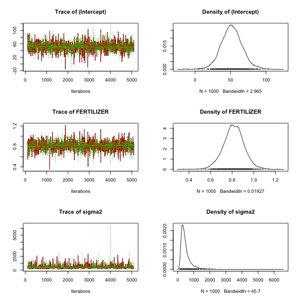

```r
fert.mcmc1 <- MCMCregress(YIELD~FERTILIZER, data=fert,
                          burnin = 100, mcmc =5000, thin=5,seed=2)
fert.mcmc2 <- MCMCregress(YIELD~FERTILIZER, data=fert,
                          burnin = 100, mcmc =5000, thin=5,seed=2)
fert.mcmc3 <- MCMCregress(YIELD~FERTILIZER, data=fert,
                          burnin = 100, mcmc =5000, thin=5,seed=3)
fert.mcmc <-as.mcmc.list(list(fert.mcmc1,fert.mcmc2,fert.mcmc3))
plot(fert.mcmc)
```

```r
autocorr.diag(fert.mcmc)
```

```
##         (Intercept)   FERTILIZER       sigma2
## Lag 0    1.00000000  1.000000000  1.000000000
## Lag 5   -0.01923931 -0.029998359 -0.036489106
## Lag 25  -0.01544306 -0.013277458 -0.022565790
## Lag 50  -0.02206422 -0.024020508 -0.007797309
## Lag 250 -0.01786679 -0.005201497  0.055493338
```

Now all looks good.

There is another diagnostic, the raftery diagnostic. Looks if you had enough samples in your chains

```r
raftery.diag(fert.mcmc)
```

```
## [[1]]
##
## Quantile (q) = 0.025
## Accuracy (r) = +/- 0.005
## Probability (s) = 0.95
##
## You need a sample size of at least 3746 with these values of q, r and s
##
## [[2]]
##
## Quantile (q) = 0.025
## Accuracy (r) = +/- 0.005
## Probability (s) = 0.95
##
## You need a sample size of at least 3746 with these values of q, r and s
##
## [[3]]
##
## Quantile (q) = 0.025
## Accuracy (r) = +/- 0.005
## Probability (s) = 0.95
##
## You need a sample size of at least 3746 with these values of q, r and s
```

Now summarize the data:

```r
summary(fert.mcmc)
```

```
##
## Iterations = 101:5096
## Thinning interval = 5
## Number of chains = 3
## Sample size per chain = 1000
##
## 1. Empirical mean and standard deviation for each variable,
##    plus standard error of the mean:
##
##                 Mean        SD Naive SE Time-series SE
## (Intercept)  51.6028  15.09567 0.275608       0.275694
## FERTILIZER    0.8136   0.09741 0.001778       0.001779
## sigma2      481.4807 326.87948 5.967975       6.082233
##
## 2. Quantiles for each variable:
##
##                 2.5%      25%      50%      75%    97.5%
## (Intercept)  22.6589  42.1738  51.3531  60.7618   83.090
## FERTILIZER    0.6177   0.7533   0.8145   0.8742    1.003
## sigma2      163.6239 280.8889 393.0157 567.4057 1304.868
```

We can now make the statement that the slope is between 0.62 and 1.0 with 95% probability. We CANNOT make the same statement with 95% confidence intervals.

```r
fert.mcmc <- rbind(fert.mcmc1, fert.mcmc2,fert.mcmc3)
head(fert.mcmc)
```

```
##      (Intercept) FERTILIZER   sigma2
## [1,]    55.38547  0.8549987 342.9582
## [2,]    46.22085  0.8643291 232.6710
## [3,]    45.03659  0.9064213 533.8965
## [4,]    91.29923  0.5449321 651.3404
## [5,]    84.76013  0.6310048 460.3705
## [6,]    40.13982  0.8640221 434.3334
```

We now have 3000 estimates of slopes (1000 per run).

We can now make a histogram with the distribution of the slopes.

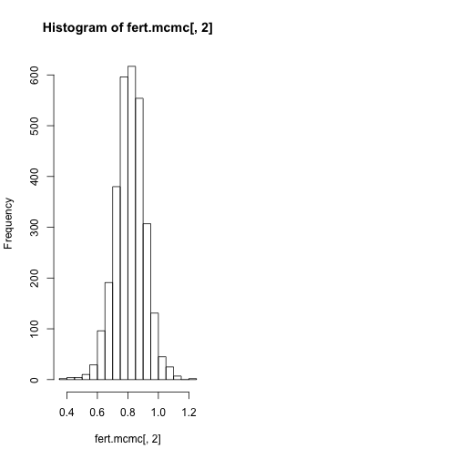

```r
par(mfrow=c(1,2))
hist(fert.mcmc[,2])
```

The estimate of the slope is the mean or the median:

```r
mean(fert.mcmc[,2])
```

```
## [1] 0.8135513
```

And the credibility intervals are:

```r
HPDinterval(as.mcmc(fert.mcmc[,2]))
```

```
##          lower     upper
## var1 0.6134619 0.9973995
## attr(,"Probability")
## [1] 0.95
```

These intervals are density based, and don't have to be equal around the mean.

In library(plyr)

```r
fert.sum <- adply(fert.mcmc,2, function(x) {
  data.frame(Mean=mean(x), Median=median(x),HPDinterval(as.mcmc(x)))
})
```

[output not shown]

In this formula, the 2 refers to the columns.

```r
head(fert.sum)
```

[output not shown]

We can now see how many times the estimate of the slope was greater than 0:count up the number of slopes greater than zero and devide this by 3000 (for the total number of iterations):

```r
table(fert.mcmc[,2]>0)
```

```
##
## TRUE
## 3000
```

```r
table(fert.mcmc[,2]>0)/length(fert.mcmc[,2])
```

```
##
## TRUE
##    1
```

We can now also test our distribution agains any hypothesis (e.g. the slope is .8):

```r
table(fert.mcmc[,2]>0.8)
```

```
##
## FALSE  TRUE
##  1312  1688
```

```r
table(fert.mcmc[,2]>0.8)/length(fert.mcmc[,2])
```

```
##
##     FALSE      TRUE
## 0.4373333 0.5626667
```

In JAGS/BUGS, things are written in terms of precision, not variance.

Model: y(i) ~ N(mu(i),tau) mu(i) = beta(0) + beta(1*x(i))

We are going to use some non-informative priors:

> beta(0) ~ *N*(0,0.000001) : the intercept is 0 with a very high uncertaincy beta(1) ~ *N*(0,0.000001) : the slope is 0 with a very high uncertaincy sigma ~ *Uniform*(0,100)

The model is (by using R to write the text file for you)

```r
modelString="
model {
  #Likelihood
  for (i in 1:n) {
    y[i]~dnorm(mu[i],tau)
    mu[i] <- beta0+beta1*x[i]
  }

  #Priors
  beta0 ~dnorm(0,1.0E-6)
  beta1 ~dnorm(0,1.0E-6)
  tau <- 1/ (sigma * sigma)
  sigma~dunif(0,100)
}
"
writeLines(modelString,con="regression.txt")
```

Now we need to create a list with out data in it. The above model is expecting x, y and n (number of rows)

```r
fert.list <- with(fert,
                  list(x=FERTILIZER,
                  y=YIELD,n=nrow(fert))
                  )
```

Now add the parameters

```r
params<- c("beta0","beta1","sigma")
```

Now put it in Jags library(R2Jags) Use the chache=TRUE command in the {r} for knitr, so it stores the data and it doesn't have to re-run every time you run knitter. Do this for any large amounts of data

```r
library("R2jags", lib.loc="/Library/Frameworks/R.framework/Versions/3.0/Resources/library")
fert.r2jags <- jags(data=fert.list,
                    inits=NULL,
                    parameters.to.save=params,
                    model.file="regression.txt",
                    n.chains=3,
                    n.iter=1000,
                    n.burnin=100,
                    n.thin=5
                    )
```

```
## module glm loaded
```

```
##    Graph Size: 50
##
```

`quartz()` can be used if figure margins are too large

```r
plot(as.mcmc(fert.r2jags))
```

[output not shown]

```r
library("R2jags", lib.loc="/Library/Frameworks/R.framework/Versions/3.0/Resources/library")
fert.r2jags2 <- jags(data=fert.list,
                    inits=NULL,
                    parameters.to.save=params,
                    model.file="regression.txt",
                    n.chains=3,
                    n.iter=10000,
                    n.burnin=1000,
                    n.thin=5
                    )
```

```
## module glm loaded
```

```
##    Graph Size: 50
##
```

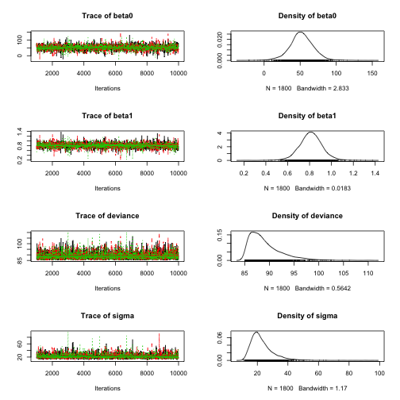

```r
plot(as.mcmc(fert.r2jags2))
```

Auto-correlation plot:

```r
autocorr.diag(as.mcmc(fert.r2jags2))
```

[output not shown]

```r
print(fert.r2jags)
```

[output not shown]

[output cut: 3638 more lines]

In this, you want n.eff to be at least half of the number of iterations. Because there is no use of calculating the mean slopes etc when you don't have a high enough number of **effective** estimates.